# Figure 2. Shifts in root microbiota structure with increasing rice tiller number under field conditions

Yong-Xin Liu

2021-12-14

# Figure 2. Shifts in root microbiota structure with increasing rice tiller number under field conditions

## 2A. Density plot showing the distribution of tiller number of 165 field-grown rice varieties. Dashed lines indicate equal-sized ranges of tiller numbers.

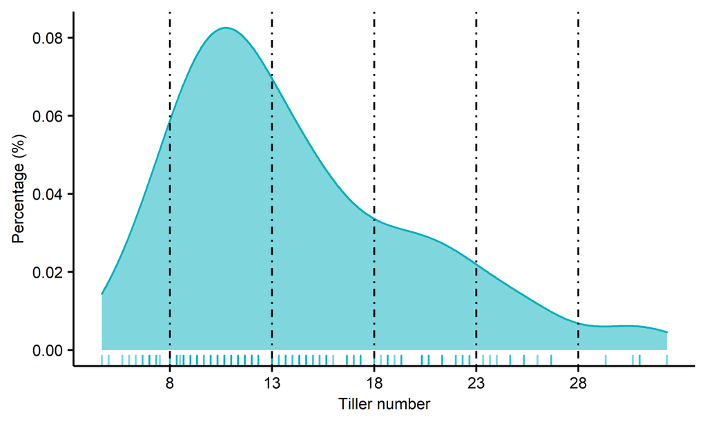

```r
phenoLN = read.table("../data/cultivar_LN_pheno.txt", header=T, row.names=1, sep="\t", comment.char="", stringsAsFactors=F)
phenoLN$soiltype = "LN"
pheno = phenoLN
step = 5
vline = sort(unique(round(pheno$tiller/step)*step+step*0.5 + 0.5))
vline = vline[1:length(vline)-1]

library(ggpubr)
(p = ggdensity(pheno, x="tiller", rug = TRUE, color = "soiltype",
               fill = "soiltype",palette = c("#00AFBB", "#E7B800")) +
    geom_vline(xintercept = vline,linetype=4)+
    xlab("Tiller number")+ylab("Percentage (%)") +
    scale_x_continuous(breaks=vline, labels=vline) +
    main_theme +theme(legend.position="none")) # add = "mean",
```

```r
ggsave(paste("2A.tiller_LN_density.pdf", sep=""), p, width = w, height = h, units = "mm")
```

1. Density plot showing the distribution of tiller number of 165 field-grown rice varieties. Dashed lines indicate equal-sized ranges of tiller numbers.

## 2B. Phylum-level distribution of root microbiota in each tiller number range. Proteobacteria are shown at the class level.

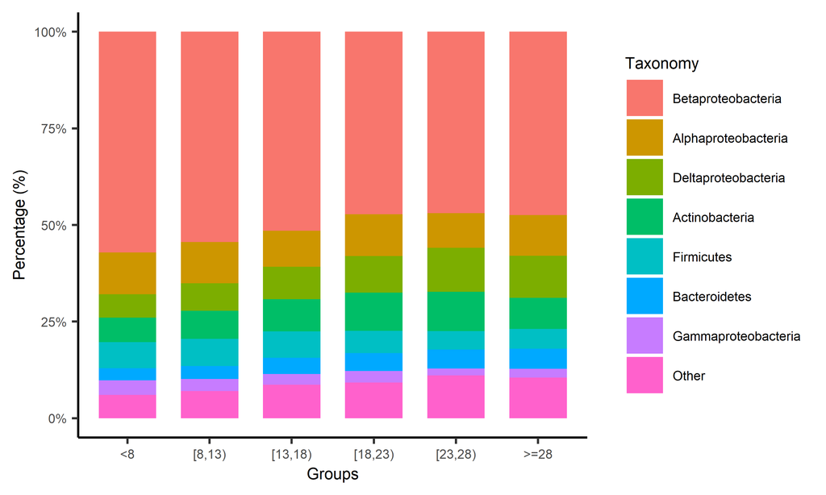

```r
metadata = read.table("../data/cultivar_LN_metadata.txt", header=T, row.names=1, sep="\t", comment.char="", stringsAsFactors=F)
level=c("<8","[8,13)","[13,18)","[18,23)","[23,28)",">=28")
metadata$group = factor(metadata$group, level)

tax_phylum = read.table(paste("../data/cultivar_LN_taxj_pc.txt",sep=""), header=T, row.names=1, sep="\t", comment.char="")

library(amplicon)
(p = tax_stackplot(tax_phylum, metadata, topN = 8, groupID = "group", style = "group", sorted = "abundance"))
```

```r
# p = p + theme(legend.position = "bottom")
ggsave(paste("2B.LN_tax_PC_tiller.pdf", sep=""), p, width = w*1.3, height = h*1.3, units = "mm")


# tax_stackplot #----
tax_sum = tax_phylum
metadata = metadata
topN = 8
groupID = "group"
style = "group"
sorted = "abundance"

p_list = c("ggplot2", "reshape2")
for (p in p_list) {
    if (!requireNamespace(p)) {
        install.packages(p)
    }
    library(p, character.only = TRUE, quietly = TRUE, warn.conflicts = FALSE)
}
idx = rownames(metadata) %in% colnames(tax_sum)
metadata = metadata[idx, ]
tax_sum = tax_sum[, rownames(metadata)]
sampFile = as.data.frame(metadata[, groupID], row.names = row.names(metadata))
colnames(sampFile)[1] = "group"
mean_sort = as.data.frame(tax_sum[(order(-rowSums(tax_sum))), ])
other = colSums(mean_sort[topN:dim(mean_sort)[1], ])
mean_sort = mean_sort[1:(topN - 1), ]
mean_sort = rbind(mean_sort, other)
rownames(mean_sort)[topN] = c("Other")
merge_tax = mean_sort

# Correlation with sample RA with tiller ranges
group.cor = as.data.frame(cor(t(mean_sort), as.numeric(gsub("T","",metadata$tiller_cat)), method = "spearman"))
library(psych)
p = corr.test(t(mean_sort), as.numeric(gsub("T","",metadata$tiller_cat)), method = "spearman")
group.cor2 = cbind(group.cor, p$p)
colnames(group.cor2)=c("Cor","Pvalue")
write.table("OTUID\t", file=paste("2B.LN_phylum_tax_cor_sample.txt",sep = ""), append = F, sep="\t", quote=F,  eol = "",row.names=F, col.names=F)
suppressWarnings(write.table(round(group.cor2,digits = 3), file=paste("2B.LN_phylum_tax_cor_sample.txt",sep = ""), append = T, sep="\t", quote=F, row.names=T, col.names=T))

mat_t = t(merge_tax)
mat_t2 = merge(sampFile, mat_t, by = "row.names")
mat_t2 = mat_t2[, c(-1)]
mat_mean = aggregate(mat_t2[, -1], by = mat_t2[1], FUN = mean)
mat_mean_final = do.call(rbind, mat_mean)[-1, ]
geno = mat_mean$group
colnames(mat_mean_final) = geno
mean_sort = as.data.frame(mat_mean_final)
mean_sort$Taxonomy = rownames(mean_sort)
data_all = as.data.frame(melt(mean_sort, id.vars = c("Taxonomy")))

# Correlation with group mean RA with tiller ranges
group.cor = as.data.frame(cor(t(mean_sort[,1:6]), 1:6, method = "spearman"))
library(psych)
p = corr.test(t(mean_sort[,1:6]), 1:6, method = "spearman")  #计算p值
# p$p
group.cor2 = cbind(group.cor, p$p)
colnames(group.cor2)=c("Cor","Pvalue")
write.table("OTUID\t", file=paste("2B.LN_phylum_tax_cor.txt",sep = ""), append = F, sep="\t", quote=F,  eol = "",row.names=F, col.names=F)
suppressWarnings(write.table(round(group.cor2,digits = 3), file=paste("2B.LN_phylum_tax_cor.txt",sep = ""), append = T, sep="\t", quote=F, row.names=T, col.names=T))
```

## 2C. Constrained PCoA with Bray–Curtis distance showing that rice varieties in each tiller number range harbored distinct root microbiota

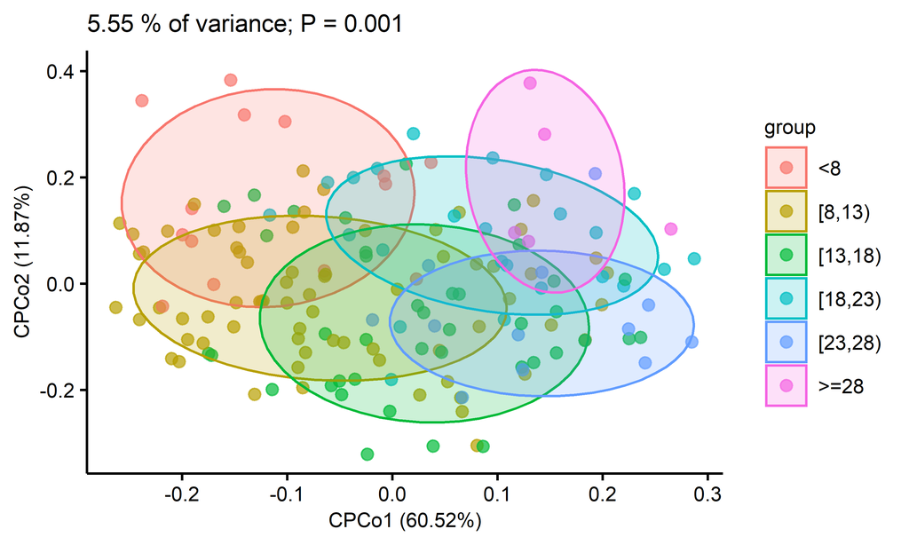

```r
metadata = read.table("../data/cultivar_LN_metadata.txt", header=T, row.names=1, sep="\t", comment.char="", stringsAsFactors=F)
# set factor level
level=c("<8","[8,13)","[13,18)","[18,23)","[23,28)",">=28")
metadata$group = factor(metadata$group, level)

sub_design = metadata
m = "bray"
beta = read.table(paste("../data/cultivar_LN_otutab_norm.txt",sep=""), header=T, row.names=1, sep="\t", comment.char="")

# Extract only those samples in common between the two tables
idx = rownames(sub_design) %in% colnames(beta)
sub_design=sub_design[idx,]
sub_beta=beta[,rownames(sub_design)]
otutab = t(sub_beta)/colSums(sub_beta,na=T)*100

# Constrained analysis OTU table by genotype
capscale.gen = capscale(otutab ~ group, data=sub_design, add=F, sqrt.dist=T, distance= m)

# ANOVA-like permutation analysis
perm_anova.gen = anova.cca(capscale.gen, permutations = 1000, parallel = 9)

# generate variability tables and calculate confidence intervals for the variance
var_tbl.gen = variability_table(capscale.gen)
eig = capscale.gen$CCA$eig
variance = var_tbl.gen["constrained", "proportion"]
p.val = perm_anova.gen[1, 4]

# extract the weighted average (sample) scores
points = capscale.gen$CCA$wa[, 1:2]
points = as.data.frame(points)

points = cbind(points, sub_design$group)
colnames(points) = c("PC1", "PC2", "group")
points$PC1 = points$PC1 * -1
points$PC2 = points$PC2 * -1

# plot PC 1 and 2
p = ggplot(points, aes(x=PC1, y=PC2, color=group)) + geom_point(alpha=.7, size=2) +
    labs(x=paste("CPCo1 (", format(100 * eig[1] / sum(eig), digits=4), "%)", sep=""),
    y=paste("CPCo2 (", format(100 * eig[2] / sum(eig), digits=4), "%)", sep="")) +
    ggtitle(paste(format(100 * variance, digits=3), " % of variance; P = ",format(p.val, digits=2),sep="")) +
    theme_classic() + main_theme
p = p + stat_ellipse(level=0.68,aes(fill = group), geom = "polygon", alpha = 0.2)
p
```

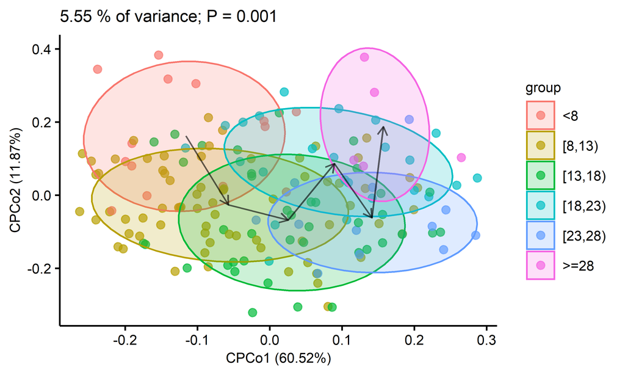

```r
# save data table
write.table("Axis\t", file=paste("2C.cpcoa.txt",sep = ""), append = F, sep="\t", quote=F,  eol = "",row.names=F, col.names=F)
suppressWarnings(write.table(points, file=paste("2C.cpcoa.txt",sep = ""), append = T, sep="\t", quote=F, row.names=T, col.names=T))


arrows_pos = points %>% group_by(group) %>% summarise_all(mean)
arrows_pos = as.data.frame(arrows_pos)
n = dim(arrows_pos)[1]
arrows_pos = cbind(arrows_pos[1:(n-1),2:3], arrows_pos[2:n,2:3])
colnames(arrows_pos) = c("x","y","xend","yend")
p = p + geom_segment(data = arrows_pos, aes(x = x, y = y, xend = xend, yend = yend),
                  arrow = arrow(length = unit(0.2, "cm")),color="black",alpha=0.6)
# p = p + theme(legend.position = "bottom")
p
```

```r
ggsave(paste("2C.LN_beta_cpcoa_tiller.pdf", sep=""), p, width = w, height = h*1.3, units = "mm")
```

3. Constrained PCoA with Bray–Curtis distance showing that rice varieties in each tiller number range harbored distinct root microbiota (P = 0.001, permutational multivariate analysis of variance by Adonis). Ellipses cover 68% of the root microbiota from varieties in each tiller range. Arrows connect the geometric center of root microbiota from low to high tiller number ranges.

## 2D. Scatter plot showing the association between root microbiota coordinates in the first axis of constrained PCoA and corresponding tiller numbers

```r
method = "spearman"
pheno = "tiller"
phenotype = read.table("../data/cultivar_LN_pheno.txt", header=T, row.names=1, sep="\t", comment.char="", stringsAsFactors=F)
beta = read.table("../fig1/1d.cpcoa.txt", header=T, row.names=1, sep="\t", comment.char="",quote="")
Subspecies = read.table(paste0("../data/cultivar.txt"), header=T, row.names=1, sep="\t", comment.char="",quote="")
beta = as.data.frame(t(beta))
# filter
idx = colnames(beta) %in% rownames(phenotype)
beta = beta[,idx]
phenotype = phenotype[colnames(beta),]

beta_mean = as.data.frame(rowMeans(beta))
beta_median = as.data.frame(apply(beta,1,median))

top = c("CAP1","CAP2")
idx = top %in% rownames(beta)
top = top[idx]
beta = beta[top,]
data = cbind(t(beta), phenotype, Subspecies[rownames(phenotype),c("Subspecies")])
colnames(data)[length(colnames(data))] = "Subspecies"

write.table("Genus\t", file=paste("2D.beta.tiller.Cor.LN.txt",sep = ""), append = F, sep="\t", quote=F,  eol = "",row.names=F, col.names=F)
suppressWarnings(write.table(data, file=paste("2D.beta.tiller.Cor.LN.txt",sep = ""), append = T, sep="\t", quote=F, row.names=T, col.names=T))

result = matrix(0, ncol = 9, nrow = ncol(t(beta)))
colnames(result) = c("feature", "env", "rho", "pvalue", "r2", "slope", "intercept", "mean", "median")

for (i in 1:length(top)){
  df = data[,c(top[i], pheno)]
  cor = cor.test(df[,1], df[,2], method = method)
  result[i,1] = colnames(df)[1]
  result[i,2] = colnames(df)[2]
  result[i,3] = cor$estimate
  result[i,4] = cor$p.value
  df2 = df
  colnames(df2) = c("x", "y")
  m = lm(y ~ x, df2)
  eqn = lm_eqn(df2)
  result[i,5] = summary(m)$r.squared
  result[i,6] = coef(m)[2]
  result[i,7] = coef(m)[1]
  result[i,8] = beta_mean[top[i],]
  result[i,9] = beta_median[top[i],]
  if (is.na(cor$estimate)){
    next;
  }
  library(RColorBrewer)
  p = ggplot(df2, aes(x, y)) +
    geom_point(size=0.7) +
    geom_smooth(method = "lm") +
    labs(x = top[i], y = pheno,
         title = paste("r = " , round(cor$estimate, digits = 2), ",p = " , signif(cor$p.value, digits = 2), ", R2 = ", round(summary(m)$r.squared, digits = 2) , sep = ""))  +  #
    theme_bw() + main_theme  + ylab("Tiller number") + theme(plot.title=element_text(size=7),text = element_text(family = "sans", size = 7), axis.text=element_text(size=7))
  ggsave(paste("2D.LN_cor", top[i], ".pdf", sep = "_"), p,  width = w, height = h, units = "mm")
}
```

4. Scatter plot showing the association between root microbiota coordinates in the first axis of constrained PCoA and corresponding tiller numbers in 165 rice varieties (P = 4.3 x 10^-13, r = 0.53).

## 2E. OTU richness of root microbiota in rice plants within each tiller number range

```r
library(amplicon)
alpha = read.table(paste("../data/cultivar_LN_alpha.txt",sep=""), header=T, row.names=1, sep="\t", comment.char="")
design = read.table("../data/cultivar_LN_metadata.txt", header=T, row.names=1, sep="\t")
level=c("<8","[8,13)","[13,18)","[18,23)","[23,28)",">=28")
design$group = factor(design$group, level)

# fiLter data
sub_design = design
idx = rownames(sub_design) %in% rownames(alpha)
sub_design=sub_design[idx,]
alpha=alpha[rownames(sub_design),]

method = c("richness","shannon_e")
for(m in method){
  alpha_index = m # "richness"
  (p = alpha_boxplot(alpha, index = alpha_index, sub_design, groupID = "group") + theme(legend.position = "none"))
  ggsave(paste("2E.LN_alpha_", alpha_index, "_tiller_group6.pdf", sep=""), p, width = w, height = h, units = "mm")
}
```

5. The Shannon index of root microbiota in rice plants within each tiller number range. The Shannon index observed in the root microbiota tended to increase with increasing tiller number. The horizontal bars within boxes represent medians. The tops and bottoms of the boxes represent the 75th and 25th percentiles, respectively. The upper and lower whiskers extend to data within no more than 1.5× the interquartile range from the upper edge and lower edge of the box, respectively. Different letters indicate significantly different groups (P < 0.05, ANOVA, Tukey’s HSD).

## 2F. Association between the Shannon indexes of root microbiota and corresponding tiller numbers

```r
method = "spearman"
pheno = "tiller"

phenotype = read.table("../data/cultivar_LN_pheno.txt", header=T, row.names=1, sep="\t", comment.char="", stringsAsFactors=F)
alpha = read.table("../data/cultivar_LN_alpha.txt", header=T, row.names=1, sep="\t", comment.char="",quote="")
Subspecies = read.table(paste0("../data/cultivar.txt"), header=T, row.names=1, sep="\t", comment.char="",quote="")
alpha = as.data.frame(t(alpha))
# filter
idx = colnames(alpha) %in% rownames(phenotype)
alpha = alpha[,idx]
phenotype = phenotype[colnames(alpha),]

alpha_mean = as.data.frame(rowMeans(alpha))
alpha_median = as.data.frame(apply(alpha,1,median))

# select alpha index
top = c("richness","shannon_e","chao1")
# filter
idx = top %in% rownames(alpha)
top = top[idx]
alpha = alpha[top,]
data = cbind(t(alpha), phenotype, Subspecies[rownames(phenotype),c("Subspecies")])
colnames(data)[length(colnames(data))] = "Subspecies"

# Save table
write.table("Genus\t", file=paste("2F.alpha.tiller.Cor.LN.txt",sep = ""), append = F, sep="\t", quote=F,  eol = "",row.names=F, col.names=F)
suppressWarnings(write.table(data, file=paste("2F.alpha.tiller.Cor.LN.txt",sep = ""), append = T, sep="\t", quote=F, row.names=T, col.names=T))

result = matrix(0, ncol = 9, nrow = ncol(t(alpha)))
colnames(result) = c("feature", "env", "rho", "pvalue", "r2", "slope", "intercept", "mean", "median")

for (i in 1:length(top)){
  df = data[,c(top[i], pheno)]
  cor = cor.test(df[,1], df[,2], method = method)
  result[i,1] = colnames(df)[1]
  result[i,2] = colnames(df)[2]
  result[i,3] = cor$estimate
  result[i,4] = cor$p.value
  df2 = df
  colnames(df2) = c("x", "y")
  m = lm(y ~ x, df2)
  eqn = lm_eqn(df2)
  result[i,5] = summary(m)$r.squared
  result[i,6] = coef(m)[2]
  result[i,7] = coef(m)[1]
  result[i,8] = alpha_mean[top[i],]
  result[i,9] = alpha_median[top[i],]
  if (is.na(cor$estimate)){
    next;
  }
  library(RColorBrewer)
  p = ggplot(df2, aes(x, y)) +
    geom_point(size=0.7) + # aes(color=group)
    geom_smooth(method = "lm") +
    labs(x = top[i], y = pheno,
         title = paste("r = " , round(cor$estimate, digits = 2), ", p = " , signif(cor$p.value, digits = 2), ", R2 = ", round(summary(m)$r.squared, digits = 2) , sep = ""))  +  # "Rho = " , round(cor$estimate, digits = 2), ",
    theme_bw() + main_theme  + ylab("Tiller number") + theme(plot.title=element_text(size=7),text = element_text(family = "sans", size = 7), axis.text=element_text(size=7))
  ggsave(paste("2F.LN_cor", top[i], ".pdf", sep = "_"), p,  width = w, height = h, units = "mm") }
```

# Figure S4. Shifts in root microbiota structure with increasing tiller number of rice varieties grown in the other test field; related to Figure 2

## S4A. Density plot showing the distribution of tiller number for 165 rice varieties grown in the other test field

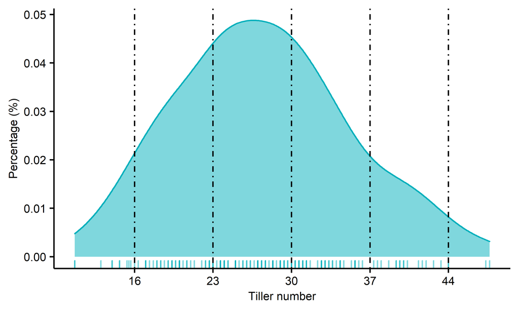

```r
phenoHN = read.table("../data/cultivar_HN_pheno.txt", header=T, row.names=1, sep="\t", comment.char="", stringsAsFactors=F)
phenoHN$soiltype = "HN"
pheno = phenoHN
step = 7
vline = sort(unique(round((pheno$tiller-5)/step)*step+step*0.5+5+0.5))
vline = vline[1:length(vline)-1]
library(ggpubr)
(p = ggdensity(pheno, x="tiller", rug = TRUE, color = "soiltype",
               fill = "soiltype",palette = c("#00AFBB", "#E7B800")) +
    geom_vline(xintercept = vline,linetype=4)+
    xlab("Tiller number")+ylab("Percentage (%)") +
    scale_x_continuous(breaks=vline, labels=vline) +
    main_theme +theme(legend.position="none")) # add = "mean",
```

```r
ggsave(paste("S4A.tiller_HN_density.pdf", sep=""), p, width = w, height = h, units = "mm")
```

1. Density plot showing the distribution of tiller number for 165 rice varieties grown in the other test field. Dashed lines indicate equal-sized ranges of tiller number.

## S4B. Phylum-level distribution of root microbiota in each tiller number range grown in other test field

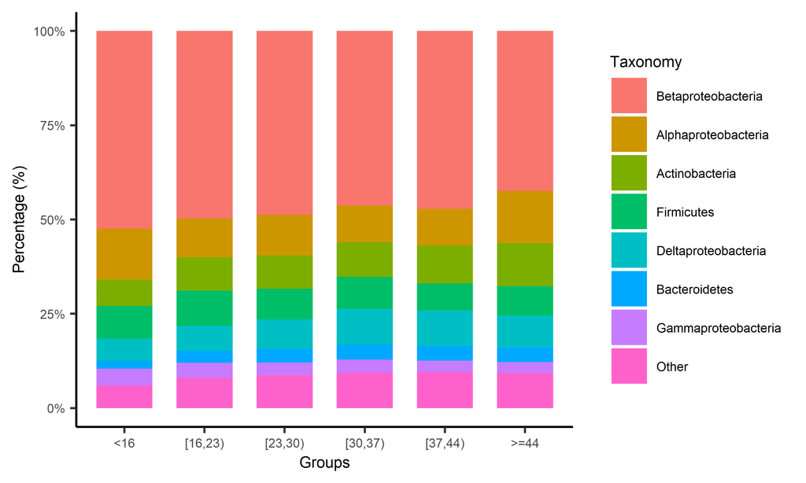

```r
metadata = read.table("../data/cultivar_HN_metadata.txt", header=T, row.names=1, sep="\t", comment.char="", stringsAsFactors=F)
level = c("<16","[16,23)","[23,30)","[30,37)","[37,44)",">=44")
metadata$group = factor(metadata$group, level)

tax_phylum = read.table(paste("../data/cultivar_HN_taxj_pc.txt",sep=""), header=T, row.names=1, sep="\t", comment.char="")

library(amplicon)
(p = tax_stackplot(tax_phylum, metadata, topN = 8, groupID = "group", style = "group", sorted = "abundance"))
```

```r
p = p + xlab("Ranges of tiller number") + theme(legend.position = "bottom")
ggsave(paste("S4B.HN_tax_PC_tiller.pdf", sep=""), p, width = w, height = h*1.3, units = "mm")

# tax_stackplot #----
tax_sum = tax_phylum
metadat = metadata
topN = 8
groupID = "group"
style = "group"
sorted = "abundance"

p_list = c("ggplot2", "reshape2")
for (p in p_list) {
    if (!requireNamespace(p)) {
        install.packages(p)
    }
    library(p, character.only = TRUE, quietly = TRUE, warn.conflicts = FALSE)
}
idx = rownames(metadata) %in% colnames(tax_sum)
metadata = metadata[idx, ]
tax_sum = tax_sum[, rownames(metadata)]
sampFile = as.data.frame(metadata[, groupID], row.names = row.names(metadata))
colnames(sampFile)[1] = "group"
mean_sort = as.data.frame(tax_sum[(order(-rowSums(tax_sum))),
    ])
other = colSums(mean_sort[topN:dim(mean_sort)[1], ])
mean_sort = mean_sort[1:(topN - 1), ]
mean_sort = rbind(mean_sort, other)
rownames(mean_sort)[topN] = c("Other")
merge_tax = mean_sort

group.cor = as.data.frame(cor(t(mean_sort), as.numeric(gsub("T","",metadata$tiller_cat)), method = "spearman"))
library(psych)
p = corr.test(t(mean_sort), as.numeric(gsub("T","",metadata$tiller_cat)), method = "spearman")
group.cor2 = cbind(group.cor, p$p)
colnames(group.cor2)=c("Cor","Pvalue")
write.table("OTUID\t", file=paste("S4B.HN_phylum_tax_cor_sample.txt",sep = ""), append = F, sep="\t", quote=F,  eol = "",row.names=F, col.names=F)
suppressWarnings(write.table(round(group.cor2,digits = 3), file=paste("S4B.HN_phylum_tax_cor_sample.txt",sep = ""), append = T, sep="\t", quote=F, row.names=T, col.names=T))

mat_t = t(merge_tax)
mat_t2 = merge(sampFile, mat_t, by = "row.names")
mat_t2 = mat_t2[, c(-1)]
mat_mean = aggregate(mat_t2[, -1], by = mat_t2[1], FUN = mean)
mat_mean_final = do.call(rbind, mat_mean)[-1, ]
geno = mat_mean$group
colnames(mat_mean_final) = geno
mean_sort = as.data.frame(mat_mean_final)
mean_sort$Taxonomy = rownames(mean_sort)
data_all = as.data.frame(melt(mean_sort, id.vars = c("Taxonomy")))

group.cor = as.data.frame(cor(t(mean_sort[,1:6]), 1:6, method = "spearman"))
library(psych)
p = corr.test(t(mean_sort[,1:6]), 1:6, method = "spearman")  #计算p值
# p$p
group.cor2 = cbind(group.cor, p$p)
colnames(group.cor2)=c("Cor","Pvalue")
write.table("OTUID\t", file=paste("S4B.HN_phylum_tax_cor.txt",sep = ""), append = F, sep="\t", quote=F,  eol = "",row.names=F, col.names=F)
suppressWarnings(write.table(round(group.cor2,digits = 3), file=paste("S4B.HN_phylum_tax_cor.txt",sep = ""), append = T, sep="\t", quote=F, row.names=T, col.names=T))
```

2. Phylum-level distribution of root microbiota in each tiller number range. Proteobacteria are shown at the class level.

## S4C. Constrained PCoA with Bray–Curtis distance showing that rice varieties in each tiller number range harbored distinct root microbiota

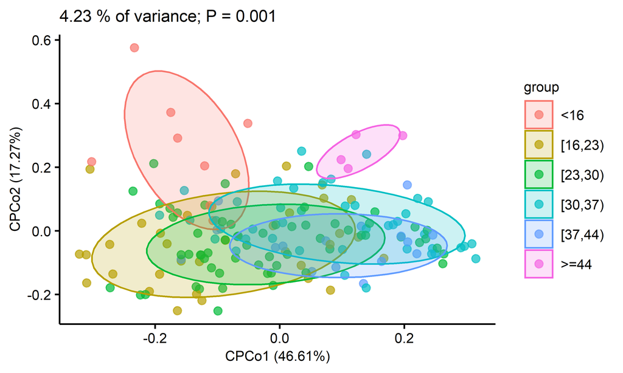

```r
metadata = read.table("../data/cultivar_HN_metadata.txt", header=T, row.names=1, sep="\t", comment.char="", stringsAsFactors=F)
level = c("<16","[16,23)","[23,30)","[30,37)","[37,44)",">=44")
metadata$group = factor(metadata$group, level)

sub_design = metadata
m = "bray"
beta = read.table(paste("../data/cultivar_HN_otutab_norm.txt",sep=""), header=T, row.names=1, sep="\t", comment.char="")

# Extract only those samples in common between the two tables
idx = rownames(sub_design) %in% colnames(beta)
sub_design=sub_design[idx,]
sub_beta=beta[,rownames(sub_design)]
otutab = t(sub_beta)/colSums(sub_beta,na=T)*100

# Constrained analysis OTU table by genotype
capscale.gen = capscale(otutab ~ group, data=sub_design, add=F, sqrt.dist=T, distance= m)

# ANOVA-like permutation analysis
perm_anova.gen = anova.cca(capscale.gen, permutations = 1000, parallel = 9)

# generate variability tables and calculate confidence intervals for the variance
var_tbl.gen = variability_table(capscale.gen)
eig = capscale.gen$CCA$eig
variance = var_tbl.gen["constrained", "proportion"]
p.val = perm_anova.gen[1, 4]

# extract the weighted average (sample) scores
points = capscale.gen$CCA$wa[, 1:2]
points = as.data.frame(points)

points = cbind(points, sub_design$group)
colnames(points) = c("PC1", "PC2", "group")
points$PC1 = points$PC1 * -1

# plot PC 1 and 2
p = ggplot(points, aes(x=PC1, y=PC2, color=group)) + geom_point(alpha=.7, size=2) +
    labs(x=paste("CPCo1 (", format(100 * eig[1] / sum(eig), digits=4), "%)", sep=""),
    y=paste("CPCo2 (", format(100 * eig[2] / sum(eig), digits=4), "%)", sep="")) +
    ggtitle(paste(format(100 * variance, digits=3), " % of variance; P = ",format(p.val, digits=2),sep="")) +
    theme_classic() + main_theme
p = p + stat_ellipse(level=0.68,aes(fill = group), geom = "polygon", alpha = 0.2)
p
```

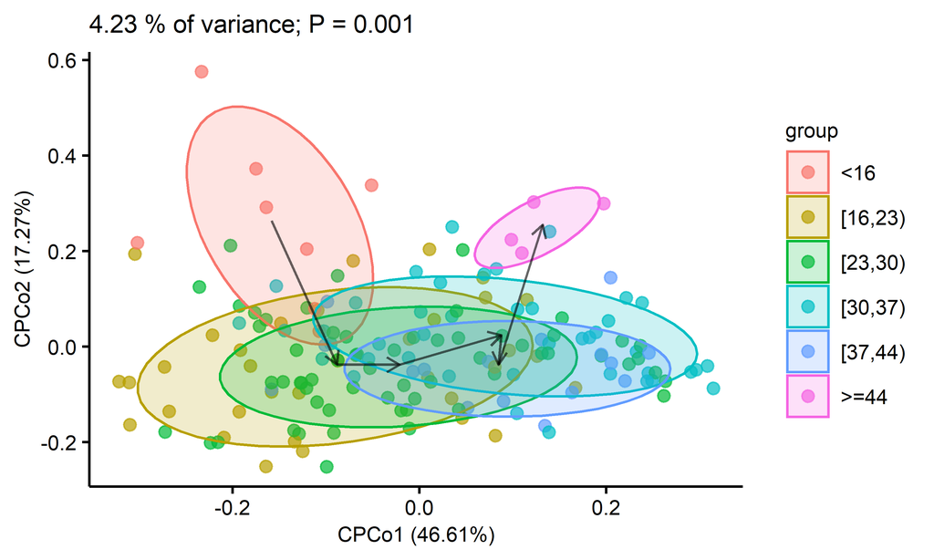

```r
# save data table
write.table("Axis\t", file=paste("S4C.cpcoa.txt",sep = ""), append = F, sep="\t", quote=F,  eol = "",row.names=F, col.names=F)
suppressWarnings(write.table(points, file=paste("S4C.cpcoa.txt",sep = ""), append = T, sep="\t", quote=F, row.names=T, col.names=T))

arrows_pos = points %>% group_by(group) %>% summarise_all(mean)
arrows_pos = as.data.frame(arrows_pos)
n = dim(arrows_pos)[1]
arrows_pos = cbind(arrows_pos[1:(n-1),2:3], arrows_pos[2:n,2:3])
colnames(arrows_pos) = c("x","y","xend","yend")
p = p + geom_segment(data = arrows_pos, aes(x = x, y = y, xend = xend, yend = yend),
                  arrow = arrow(length = unit(0.2, "cm")),color="black",alpha=0.6)
# p = p + theme(legend.position = "bottom")
p
```

```r
ggsave(paste("S4C.HN_beta_cpcoa_tiller.pdf", sep=""), p, width = w, height = h*1.3, units = "mm")
```

3. Constrained PCoA with Bray–Curtis distance showing that rice varieties in each tiller number range harbored distinct root microbiota (P = 0.001, permutational multivariate analysis of variance by Adonis). Ellipses cover 68% of the root microbiota from varieties in each tiller range. Arrows connect the geometric center of root microbiota from low to high tiller number ranges.

## S4D. Association between root microbiota coordinates in the first axis of constrained PCoA

```r
method = "spearman"
pheno = "tiller"
phenotype = read.table("../data/cultivar_HN_pheno.txt", header=T, row.names=1, sep="\t", comment.char="", stringsAsFactors=F)
beta = read.table("../fig1/HN_cpcoa.txt", header=T, row.names=1, sep="\t", comment.char="",quote="")
Subspecies = read.table(paste0("../data/cultivar.txt"), header=T, row.names=1, sep="\t", comment.char="",quote="")
beta = as.data.frame(t(beta))
# filter
idx = colnames(beta) %in% rownames(phenotype)
beta = beta[,idx]
phenotype = phenotype[colnames(beta),]

beta_mean = as.data.frame(rowMeans(beta))
beta_median = as.data.frame(apply(beta,1,median))

top = c("CAP1","CAP2")
idx = top %in% rownames(beta)
top = top[idx]
beta = beta[top,]
data = cbind(t(beta), phenotype, Subspecies[rownames(phenotype),c("Subspecies")])
colnames(data)[length(colnames(data))] = "Subspecies"

write.table("Genus\t", file=paste("S4D.beta.tiller.Cor.HN.txt",sep = ""), append = F, sep="\t", quote=F,  eol = "",row.names=F, col.names=F)
suppressWarnings(write.table(data, file=paste("S4D.beta.tiller.Cor.HN.txt",sep = ""), append = T, sep="\t", quote=F, row.names=T, col.names=T))

result = matrix(0, ncol = 9, nrow = ncol(t(beta)))
colnames(result) = c("feature", "env", "rho", "pvalue", "r2", "slope", "intercept", "mean", "median")

for (i in 1:length(top)){
  df = data[,c(top[i], pheno)]
  cor = cor.test(df[,1], df[,2], method = method)
  result[i,1] = colnames(df)[1]
  result[i,2] = colnames(df)[2]
  result[i,3] = cor$estimate
  result[i,4] = cor$p.value
  df2 = df
  colnames(df2) = c("x", "y")
  m = lm(y ~ x, df2)
  eqn = lm_eqn(df2)
  result[i,5] = summary(m)$r.squared
  result[i,6] = coef(m)[2]
  result[i,7] = coef(m)[1]
  result[i,8] = beta_mean[top[i],]
  result[i,9] = beta_median[top[i],]
  if (is.na(cor$estimate)){
    next;
  }
  library(RColorBrewer)
  p = ggplot(df2, aes(x, y)) +
    geom_point(size=0.7) +
    geom_smooth(method = "lm") +
    labs(x = top[i], y = pheno,
         title = paste("r = " , round(cor$estimate, digits = 2), ",p = " , signif(cor$p.value, digits = 2), ", R2 = ", round(summary(m)$r.squared, digits = 2) , sep = ""))  +  #
    theme_bw() + main_theme  + ylab("Tiller number") + theme(plot.title=element_text(size=7),text = element_text(family = "sans", size = 7), axis.text=element_text(size=7))
  ggsave(paste("S4D.HN_cor", top[i], ".pdf", sep = "_"), p,  width = w, height = h, units = "mm")
}
```

4. Scatter plot showing the association between root microbiota coordinates in the first axis of constrained PCoA and corresponding tiller numbers in 165 rice varieties (P = 1.3 x 10^-7, r = 0.40).

## S4E. OTU shannon index of root microbiota in rice plants within each tiller number range

```r
library(amplicon)
alpha = read.table(paste("../data/cultivar_HN_alpha.txt",sep=""), header=T, row.names=1, sep="\t", comment.char="")
design = read.table("../data/cultivar_HN_metadata.txt", header=T, row.names=1, sep="\t")
level = c("<16","[16,23)","[23,30)","[30,37)","[37,44)",">=44")
design$group = factor(design$group, level)

# filter data
sub_design = design
idx = rownames(sub_design) %in% rownames(alpha)
sub_design=sub_design[idx,]
alpha=alpha[rownames(sub_design),]

method = c("richness","shannon_e")
for(m in method){
  alpha_index = m # "richness"
  (p = alpha_boxplot(alpha, index = alpha_index, sub_design, groupID = "group")+main_theme + theme(legend.position = "none")+
    xlab("Ranges of tiller number")
    )
  ggsave(paste("S4E.HN_alpha_", alpha_index, "_tiller_group6.pdf", sep=""), p, width = w, height = h, units = "mm")
}
```

5. The Shannon index of root microbiota in rice plants within each tiller number range. The Shannon index observed in the root microbiota tended to increase with increasing tiller number. The horizontal bars within boxes represent medians. The tops and bottoms of the boxes represent the 75th and 25th percentiles, respectively. The upper and lower whiskers extend to data within no more than 1.5× the interquartile range from the upper edge and lower edge of the box, respectively. Different letters indicate significantly different groups (P < 0.05, ANOVA, Tukey’s HSD).

## S4F. Association between the Shannon indexes of root microbiota and corresponding tiller numbers in field II

```r
method = "spearman"
pheno = "tiller"

phenotype = read.table("../data/cultivar_HN_pheno.txt", header=T, row.names=1, sep="\t", comment.char="", stringsAsFactors=F)
alpha = read.table("../data/cultivar_HN_alpha.txt", header=T, row.names=1, sep="\t", comment.char="",quote="")
Subspecies = read.table(paste0("../data/cultivar.txt"), header=T, row.names=1, sep="\t", comment.char="",quote="")
alpha = as.data.frame(t(alpha))
# filter
idx = colnames(alpha) %in% rownames(phenotype)
alpha = alpha[,idx]
phenotype = phenotype[colnames(alpha),]

alpha_mean = as.data.frame(rowMeans(alpha))
alpha_median = as.data.frame(apply(alpha,1,median))

# select alpha index
top = c("richness","shannon_e","chao1")
# filter
idx = top %in% rownames(alpha)
top = top[idx]
alpha = alpha[top,]
data = cbind(t(alpha), phenotype, Subspecies[rownames(phenotype),c("Subspecies")])
colnames(data)[length(colnames(data))] = "Subspecies"

# Save table
write.table("Genus\t", file=paste("S4F.alpha.tiller.Cor.HN.txt",sep = ""), append = F, sep="\t", quote=F,  eol = "",row.names=F, col.names=F)
suppressWarnings(write.table(data, file=paste("S4F.alpha.tiller.Cor.HN.txt",sep = ""), append = T, sep="\t", quote=F, row.names=T, col.names=T))

result = matrix(0, ncol = 9, nrow = ncol(t(alpha)))
colnames(result) = c("feature", "env", "rho", "pvalue", "r2", "slope", "intercept", "mean", "median")

for (i in 1:length(top)){
  df = data[,c(top[i], pheno)]
  cor = cor.test(df[,1], df[,2], method = method)
  result[i,1] = colnames(df)[1]
  result[i,2] = colnames(df)[2]
  result[i,3] = cor$estimate
  result[i,4] = cor$p.value
  df2 = df
  colnames(df2) = c("x", "y")
  m = lm(y ~ x, df2)
  eqn = lm_eqn(df2)
  result[i,5] = summary(m)$r.squared
  result[i,6] = coef(m)[2]
  result[i,7] = coef(m)[1]
  result[i,8] = alpha_mean[top[i],]
  result[i,9] = alpha_median[top[i],]
  if (is.na(cor$estimate)){
    next;
  }
  library(RColorBrewer)
  p = ggplot(df2, aes(x, y)) +
    geom_point(size=0.7) + # aes(color=group)
    geom_smooth(method = "lm") +
    labs(x = top[i], y = pheno,
         title = paste("r = " , round(cor$estimate, digits = 2), ", p = " , signif(cor$p.value, digits = 2), ", R2 = ", round(summary(m)$r.squared, digits = 2) , sep = ""))  +  # "Rho = " , round(cor$estimate, digits = 2), ",
    theme_bw() + main_theme  + ylab("Tiller number") + theme(plot.title=element_text(size=7),text = element_text(family = "sans", size = 7), axis.text=element_text(size=7))
  ggsave(paste("S4F.HN_cor", top[i], ".pdf", sep = "_"), p,  width = w, height = h, units = "mm") }
```